# City crime data summary

The data for Tucson included in the Crime Open Database (CODE) includes records for 1,405,226 offences between 2009 and 2017.

# Excluded cases

| Reason | Cases |
| --- | --- |
| Total | 1,405,226 |
| Incomplete co-ordinates | 0 |
| Location outside city | 13,716 |
| Non-criminal matters | NA |
| Non-Reportable Crimes | NA |
| Non-Categorisable Offenses | NA |

# Temporal distribution

The daily count of crimes varies between 129 and 318 offenses per day, with a median of 226:

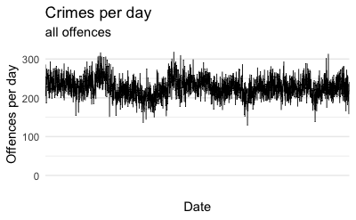

There is seasonal variation in overall crime:

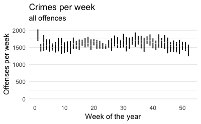

There is variation in the frequency of crime across weekdays:

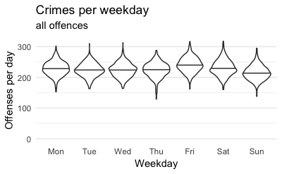

and hours of the day:

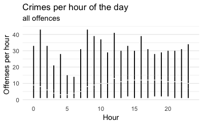

# Spatial distribution

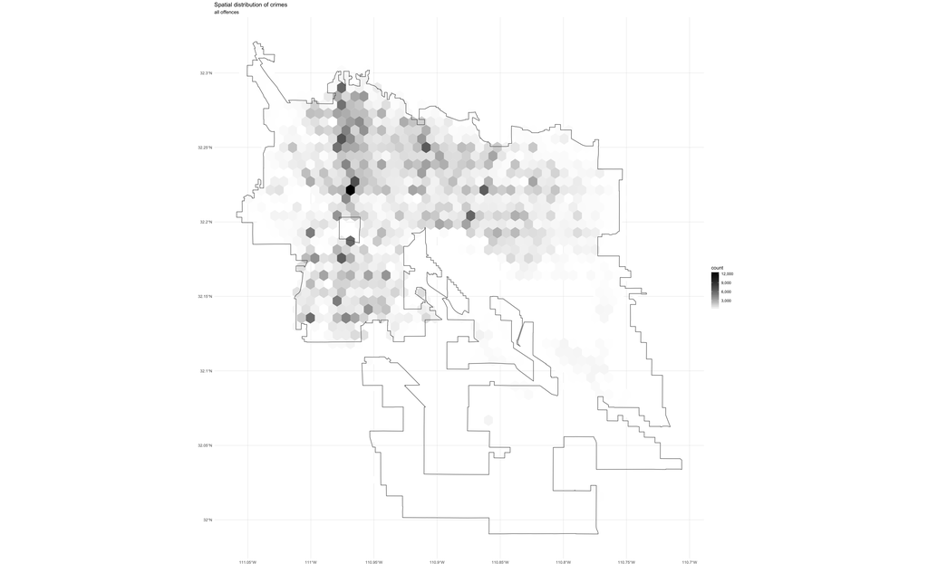

```r
city_outline <- st_read(paste0("../spatial_data/cities/tl_2016_",
                               cities$fips[cities$name == this_city],
                               "_place.shp"), quiet = TRUE) %>%
  filter(NAME == this_city)
city_bbox <- st_bbox(city_outline)
ggplot() +
  geom_sf(data = tigris::states(year = 2016, class = "sf"),
          fill = NA, colour = "#999999") +
  geom_hex(
    mapping = aes(x = longitude, y = latitude),
    data = filter(data, !is.na(latitude) & !is.na(longitude)),
    bins = 50
  ) +
  geom_sf(
    data = city_outline, fill = NA
  ) +
  lims(x = c(city_bbox$xmin, city_bbox$xmax),
       y = c(city_bbox$ymin, city_bbox$ymax)) +
  scale_fill_continuous(low = "#FFFFFF", high = "#000000",
                        label = scales::comma) +
  labs(title = "Spatial distribution of crimes", subtitle = "all offences",
       x = "", y = "") +
  theme_minimal() +
  theme(
    panel.grid.major = element_line(colour = "#CCCCCC")
  )
```

# Crime types

Offenses in the CODE data are split into three categories: crimes against people, property and society. These categories are then split into smaller categories for different offense types.

## Crimes against people

| Group | Type | Cases |
| --- | --- | --- |
| homicide offenses | murder and nonnegligent manslaughter | 382 |
| homicide offenses | negligent manslaughter | 9 |
| kidnapping/abduction | kidnapping/abduction | 171 |
| sex offenses | rape (except statutory rape) | 2,556 |
| sex offenses | fondling | 3,246 |
| assault offenses | aggravated assault | 14,738 |
| assault offenses | simple assault | 79,616 |
| assault offenses | intimidation | 290 |
| sex offenses | other sex offenses | 2,250 |
| human trafficking | human trafficking, commercial sex acts | 46 |

[output cut: 1 more lines]

## Crimes against property

| Group | Type | Cases |
| --- | --- | --- |
| robbery | personal robbery | 6,158 |
| robbery | commercial robbery | 3,255 |
| robbery | other robbery | 731 |
| arson | arson | 1,533 |
| burglary/breaking & entering | other burglary/breaking & entering | 52,337 |
| larceny/theft offenses | pocket-picking | 459 |
| larceny/theft offenses | purse-snatching | 572 |
| larceny/theft offenses | shoplifting | 114,820 |
| larceny/theft offenses | theft from building | 18,645 |
| larceny/theft offenses | theft from coin-operated machine or dev … | 440 |

[output cut: 12 more lines]

## Crimes against society

| Group | Type | Cases |
| --- | --- | --- |
| drug/narcotic offenses | drug/narcotic violations | 35,327 |
| drug/narcotic offenses | drug equipment violations | 14,133 |
| prostitution offenses | prostitution | 1,167 |
| weapon law violations | weapon law violations | 2,953 |
| curfew/loitering/vagrancy violations | curfew/loitering/vagrancy violations | 2,070 |
| disorderly conduct | disorderly conduct | 34,280 |
| driving under the influence | driving under the influence | 20,467 |
| drunkenness (except driving under the i … | drunkenness (except driving under the i … | 1,005 |
| family offenses, nonviolent | family offenses, nonviolent | 8,158 |
| liquor law violations (except driving u … | liquor law violations (except driving u … | 7,548 |

[output cut: 2 more lines]

## Crime types missing from the data

```r
if (length(missing_types) > 0) {
  cat("Some types of crime are missing from the", this_city, "data:\n\n")
  cat(paste("  *", missing_types), sep = "\n")
}
```

Some types of crime are missing from the Tucson data:

- 11b Sodomy
- 11c Sexual Assault With An Object
- 210 Extortion/Blackmail
- 22a Residential Burglary/Breaking & Entering
- 22b Non-Residential Burglary/Breaking & Entering
- 26b Credit Card/Automated Teller Machine Fraud
- 26d Welfare Fraud
- 26e Wire Fraud
- 36a Incest
- 36b Statutory Rape
- 370 Pornography/Obscene Material
- 39a Betting/Wagering
- 39b Operating/Promoting/Assisting Gambling
- 39c Gambling Equipment Violations
- 39d Sports Tampering
- 40b Assisting Or Promoting Prostitution
- 40c Purchasing Prostitution
- 510 Bribery

```r
other_cats <- data %>%
  filter(str_sub(offense_code, 3, 3) == "U") %>%
  mutate(Type = paste(offense_code, offense_type)) %>%
  group_by(Type) %>%
  summarise(Cases = n()) %>%
  mutate(Cases = format(Cases, big.mark = ","))
if (nrow(other_cats) > 0) {
  cat("Due to limitations in the matching process between crime types in the",
      "original data and the CODE crime categories, some crimes have been",
      "coded to an 'other' category within the relevent higher-level category.",
      "Specifically, crimes have been coded to the following 'other'",
      "categories:", "\n\n")
}
```

Due to limitations in the matching process between crime types in the original data and the CODE crime categories, some crimes have been coded to an ‘other’ category within the relevent higher-level category. Specifically, crimes have been coded to the following ‘other’ categories:

| Type | Cases |
| --- | --- |
| 12U other robbery | 731 |
| 22U other burglary/breaking & entering | 52,337 |
| 26U other fraud | 12,918 |
| 36U other sex offenses | 2,250 |